# Risk Factor Analysis

## Outcome Variable

**Outcome Variable:** ever_stunted

## Predictor Variables

**Intervention Variable:** lag_WHZ_quart

**Adjustment Set:**

- arm
- sex
- W_mage
- meducyrs
- feducyrs
- single
- month
- brthmon
- delta_W_mage
- delta_meducyrs
- delta_feducyrs
- delta_single
- delta_month
- delta_brthmon

## Stratifying Variables

The analysis was stratified on these variable(s):

- agecat
- studyid
- country

## Data Summary

| agecat | studyid | country | lag_WHZ_quart | ever_stunted | n_cell | n |
| --- | --- | --- | --- | --- | --- | --- |
| 3-6 months | ki0047075b-MAL-ED | BANGLADESH | 1 | 0 | 43 | 207 |
| 3-6 months | ki0047075b-MAL-ED | BANGLADESH | 1 | 1 | 5 | 207 |
| 3-6 months | ki0047075b-MAL-ED | BANGLADESH | 2 | 0 | 78 | 207 |
| 3-6 months | ki0047075b-MAL-ED | BANGLADESH | 2 | 1 | 14 | 207 |
| 3-6 months | ki0047075b-MAL-ED | BANGLADESH | 3 | 0 | 51 | 207 |
| 3-6 months | ki0047075b-MAL-ED | BANGLADESH | 3 | 1 | 8 | 207 |
| 3-6 months | ki0047075b-MAL-ED | BANGLADESH | 4 | 0 | 7 | 207 |
| 3-6 months | ki0047075b-MAL-ED | BANGLADESH | 4 | 1 | 1 | 207 |
| 3-6 months | ki0047075b-MAL-ED | BRAZIL | 1 | 0 | 32 | 201 |
| 3-6 months | ki0047075b-MAL-ED | BRAZIL | 1 | 1 | 1 | 201 |
| 3-6 months | ki0047075b-MAL-ED | BRAZIL | 2 | 0 | 90 | 201 |
| 3-6 months | ki0047075b-MAL-ED | BRAZIL | 2 | 1 | 5 | 201 |
| 3-6 months | ki0047075b-MAL-ED | BRAZIL | 3 | 0 | 50 | 201 |
| 3-6 months | ki0047075b-MAL-ED | BRAZIL | 3 | 1 | 3 | 201 |
| 3-6 months | ki0047075b-MAL-ED | BRAZIL | 4 | 0 | 16 | 201 |
| 3-6 months | ki0047075b-MAL-ED | BRAZIL | 4 | 1 | 4 | 201 |
| 3-6 months | ki0047075b-MAL-ED | INDIA | 1 | 0 | 65 | 199 |
| 3-6 months | ki0047075b-MAL-ED | INDIA | 1 | 1 | 13 | 199 |
| 3-6 months | ki0047075b-MAL-ED | INDIA | 2 | 0 | 65 | 199 |
| 3-6 months | ki0047075b-MAL-ED | INDIA | 2 | 1 | 9 | 199 |
| 3-6 months | ki0047075b-MAL-ED | INDIA | 3 | 0 | 30 | 199 |
| 3-6 months | ki0047075b-MAL-ED | INDIA | 3 | 1 | 8 | 199 |
| 3-6 months | ki0047075b-MAL-ED | INDIA | 4 | 0 | 4 | 199 |
| 3-6 months | ki0047075b-MAL-ED | INDIA | 4 | 1 | 5 | 199 |
| 3-6 months | ki0047075b-MAL-ED | NEPAL | 1 | 0 | 43 | 210 |
| 3-6 months | ki0047075b-MAL-ED | NEPAL | 1 | 1 | 0 | 210 |
| 3-6 months | ki0047075b-MAL-ED | NEPAL | 2 | 0 | 80 | 210 |
| 3-6 months | ki0047075b-MAL-ED | NEPAL | 2 | 1 | 2 | 210 |
| 3-6 months | ki0047075b-MAL-ED | NEPAL | 3 | 0 | 68 | 210 |
| 3-6 months | ki0047075b-MAL-ED | NEPAL | 3 | 1 | 3 | 210 |

[output cut: 882 more lines]

The following strata were considered:

- agecat: 12-15 months, studyid: ki0047075b-MAL-ED, country: BANGLADESH
- agecat: 12-15 months, studyid: ki0047075b-MAL-ED, country: BRAZIL
- agecat: 12-15 months, studyid: ki0047075b-MAL-ED, country: INDIA
- agecat: 12-15 months, studyid: ki0047075b-MAL-ED, country: NEPAL
- agecat: 12-15 months, studyid: ki0047075b-MAL-ED, country: PERU
- agecat: 12-15 months, studyid: ki0047075b-MAL-ED, country: SOUTH AFRICA
- agecat: 12-15 months, studyid: ki0047075b-MAL-ED, country: TANZANIA, UNITED REPUBLIC OF
- agecat: 12-15 months, studyid: ki1000108-CMC-V-BCS-2002, country: INDIA
- agecat: 12-15 months, studyid: ki1000108-IRC, country: INDIA
- agecat: 12-15 months, studyid: ki1000109-EE, country: PAKISTAN
- agecat: 12-15 months, studyid: ki1017093b-PROVIDE, country: BANGLADESH
- agecat: 12-15 months, studyid: ki1066203-TanzaniaChild2, country: TANZANIA, UNITED REPUBLIC OF
- agecat: 12-15 months, studyid: ki1101329-Keneba, country: GAMBIA
- agecat: 12-15 months, studyid: ki1112895-Guatemala BSC, country: GUATEMALA
- agecat: 12-15 months, studyid: ki1113344-GMS-Nepal, country: NEPAL
- agecat: 12-15 months, studyid: ki1114097-CMIN, country: BANGLADESH
- agecat: 12-15 months, studyid: ki1114097-CMIN, country: PERU
- agecat: 15-18 months, studyid: ki0047075b-MAL-ED, country: BANGLADESH
- agecat: 15-18 months, studyid: ki0047075b-MAL-ED, country: BRAZIL
- agecat: 15-18 months, studyid: ki0047075b-MAL-ED, country: INDIA
- agecat: 15-18 months, studyid: ki0047075b-MAL-ED, country: NEPAL
- agecat: 15-18 months, studyid: ki0047075b-MAL-ED, country: PERU
- agecat: 15-18 months, studyid: ki0047075b-MAL-ED, country: SOUTH AFRICA
- agecat: 15-18 months, studyid: ki0047075b-MAL-ED, country: TANZANIA, UNITED REPUBLIC OF
- agecat: 15-18 months, studyid: ki1000108-CMC-V-BCS-2002, country: INDIA
- agecat: 15-18 months, studyid: ki1000108-IRC, country: INDIA
- agecat: 15-18 months, studyid: ki1000109-EE, country: PAKISTAN
- agecat: 15-18 months, studyid: ki1017093b-PROVIDE, country: BANGLADESH
- agecat: 15-18 months, studyid: ki1066203-TanzaniaChild2, country: TANZANIA, UNITED REPUBLIC OF
- agecat: 15-18 months, studyid: ki1101329-Keneba, country: GAMBIA
- agecat: 15-18 months, studyid: ki1112895-Guatemala BSC, country: GUATEMALA
- agecat: 15-18 months, studyid: ki1113344-GMS-Nepal, country: NEPAL
- agecat: 15-18 months, studyid: ki1114097-CMIN, country: BANGLADESH
- agecat: 15-18 months, studyid: ki1114097-CMIN, country: PERU
- agecat: 18-21 months, studyid: ki0047075b-MAL-ED, country: BANGLADESH
- agecat: 18-21 months, studyid: ki0047075b-MAL-ED, country: BRAZIL
- agecat: 18-21 months, studyid: ki0047075b-MAL-ED, country: INDIA
- agecat: 18-21 months, studyid: ki0047075b-MAL-ED, country: NEPAL
- agecat: 18-21 months, studyid: ki0047075b-MAL-ED, country: PERU
- agecat: 18-21 months, studyid: ki0047075b-MAL-ED, country: SOUTH AFRICA
- agecat: 18-21 months, studyid: ki0047075b-MAL-ED, country: TANZANIA, UNITED REPUBLIC OF
- agecat: 18-21 months, studyid: ki1000108-CMC-V-BCS-2002, country: INDIA
- agecat: 18-21 months, studyid: ki1000108-IRC, country: INDIA
- agecat: 18-21 months, studyid: ki1000109-EE, country: PAKISTAN
- agecat: 18-21 months, studyid: ki1017093b-PROVIDE, country: BANGLADESH
- agecat: 18-21 months, studyid: ki1066203-TanzaniaChild2, country: TANZANIA, UNITED REPUBLIC OF
- agecat: 18-21 months, studyid: ki1101329-Keneba, country: GAMBIA
- agecat: 18-21 months, studyid: ki1113344-GMS-Nepal, country: NEPAL
- agecat: 18-21 months, studyid: ki1114097-CMIN, country: BANGLADESH
- agecat: 18-21 months, studyid: ki1114097-CMIN, country: PERU
- agecat: 21-24 months, studyid: ki0047075b-MAL-ED, country: BANGLADESH
- agecat: 21-24 months, studyid: ki0047075b-MAL-ED, country: BRAZIL
- agecat: 21-24 months, studyid: ki0047075b-MAL-ED, country: INDIA
- agecat: 21-24 months, studyid: ki0047075b-MAL-ED, country: NEPAL
- agecat: 21-24 months, studyid: ki0047075b-MAL-ED, country: PERU
- agecat: 21-24 months, studyid: ki0047075b-MAL-ED, country: SOUTH AFRICA
- agecat: 21-24 months, studyid: ki0047075b-MAL-ED, country: TANZANIA, UNITED REPUBLIC OF
- agecat: 21-24 months, studyid: ki1000108-CMC-V-BCS-2002, country: INDIA
- agecat: 21-24 months, studyid: ki1000108-IRC, country: INDIA
- agecat: 21-24 months, studyid: ki1017093b-PROVIDE, country: BANGLADESH
- agecat: 21-24 months, studyid: ki1066203-TanzaniaChild2, country: TANZANIA, UNITED REPUBLIC OF
- agecat: 21-24 months, studyid: ki1101329-Keneba, country: GAMBIA
- agecat: 21-24 months, studyid: ki1113344-GMS-Nepal, country: NEPAL
- agecat: 21-24 months, studyid: ki1114097-CMIN, country: BANGLADESH
- agecat: 21-24 months, studyid: ki1114097-CMIN, country: PERU
- agecat: 3-6 months, studyid: ki0047075b-MAL-ED, country: BANGLADESH
- agecat: 3-6 months, studyid: ki0047075b-MAL-ED, country: BRAZIL
- agecat: 3-6 months, studyid: ki0047075b-MAL-ED, country: INDIA
- agecat: 3-6 months, studyid: ki0047075b-MAL-ED, country: NEPAL
- agecat: 3-6 months, studyid: ki0047075b-MAL-ED, country: PERU
- agecat: 3-6 months, studyid: ki0047075b-MAL-ED, country: SOUTH AFRICA
- agecat: 3-6 months, studyid: ki0047075b-MAL-ED, country: TANZANIA, UNITED REPUBLIC OF
- agecat: 3-6 months, studyid: ki1000108-CMC-V-BCS-2002, country: INDIA
- agecat: 3-6 months, studyid: ki1000108-IRC, country: INDIA
- agecat: 3-6 months, studyid: ki1000109-EE, country: PAKISTAN
- agecat: 3-6 months, studyid: ki1017093b-PROVIDE, country: BANGLADESH
- agecat: 3-6 months, studyid: ki1066203-TanzaniaChild2, country: TANZANIA, UNITED REPUBLIC OF
- agecat: 3-6 months, studyid: ki1101329-Keneba, country: GAMBIA
- agecat: 3-6 months, studyid: ki1112895-Guatemala BSC, country: GUATEMALA
- agecat: 3-6 months, studyid: ki1114097-CMIN, country: BANGLADESH
- agecat: 3-6 months, studyid: ki1114097-CMIN, country: PERU
- agecat: 6-9 months, studyid: ki0047075b-MAL-ED, country: BANGLADESH
- agecat: 6-9 months, studyid: ki0047075b-MAL-ED, country: BRAZIL
- agecat: 6-9 months, studyid: ki0047075b-MAL-ED, country: INDIA
- agecat: 6-9 months, studyid: ki0047075b-MAL-ED, country: NEPAL
- agecat: 6-9 months, studyid: ki0047075b-MAL-ED, country: PERU
- agecat: 6-9 months, studyid: ki0047075b-MAL-ED, country: SOUTH AFRICA
- agecat: 6-9 months, studyid: ki0047075b-MAL-ED, country: TANZANIA, UNITED REPUBLIC OF
- agecat: 6-9 months, studyid: ki1000108-CMC-V-BCS-2002, country: INDIA
- agecat: 6-9 months, studyid: ki1000108-IRC, country: INDIA
- agecat: 6-9 months, studyid: ki1000109-EE, country: PAKISTAN
- agecat: 6-9 months, studyid: ki1017093b-PROVIDE, country: BANGLADESH
- agecat: 6-9 months, studyid: ki1066203-TanzaniaChild2, country: TANZANIA, UNITED REPUBLIC OF
- agecat: 6-9 months, studyid: ki1101329-Keneba, country: GAMBIA
- agecat: 6-9 months, studyid: ki1112895-Guatemala BSC, country: GUATEMALA
- agecat: 6-9 months, studyid: ki1114097-CMIN, country: BANGLADESH
- agecat: 6-9 months, studyid: ki1114097-CMIN, country: PERU
- agecat: 9-12 months, studyid: ki0047075b-MAL-ED, country: BANGLADESH
- agecat: 9-12 months, studyid: ki0047075b-MAL-ED, country: BRAZIL
- agecat: 9-12 months, studyid: ki0047075b-MAL-ED, country: INDIA
- agecat: 9-12 months, studyid: ki0047075b-MAL-ED, country: NEPAL
- agecat: 9-12 months, studyid: ki0047075b-MAL-ED, country: PERU
- agecat: 9-12 months, studyid: ki0047075b-MAL-ED, country: SOUTH AFRICA
- agecat: 9-12 months, studyid: ki0047075b-MAL-ED, country: TANZANIA, UNITED REPUBLIC OF
- agecat: 9-12 months, studyid: ki1000108-CMC-V-BCS-2002, country: INDIA
- agecat: 9-12 months, studyid: ki1000108-IRC, country: INDIA
- agecat: 9-12 months, studyid: ki1000109-EE, country: PAKISTAN
- agecat: 9-12 months, studyid: ki1017093b-PROVIDE, country: BANGLADESH
- agecat: 9-12 months, studyid: ki1066203-TanzaniaChild2, country: TANZANIA, UNITED REPUBLIC OF
- agecat: 9-12 months, studyid: ki1101329-Keneba, country: GAMBIA
- agecat: 9-12 months, studyid: ki1112895-Guatemala BSC, country: GUATEMALA
- agecat: 9-12 months, studyid: ki1113344-GMS-Nepal, country: NEPAL
- agecat: 9-12 months, studyid: ki1114097-CMIN, country: BANGLADESH
- agecat: 9-12 months, studyid: ki1114097-CMIN, country: PERU

### Dropped Strata

Some strata were dropped due to rare outcomes:

- agecat: 3-6 months, studyid: ki0047075b-MAL-ED, country: BANGLADESH
- agecat: 3-6 months, studyid: ki0047075b-MAL-ED, country: BRAZIL
- agecat: 3-6 months, studyid: ki0047075b-MAL-ED, country: INDIA
- agecat: 3-6 months, studyid: ki0047075b-MAL-ED, country: NEPAL
- agecat: 3-6 months, studyid: ki0047075b-MAL-ED, country: PERU
- agecat: 3-6 months, studyid: ki0047075b-MAL-ED, country: SOUTH AFRICA
- agecat: 3-6 months, studyid: ki0047075b-MAL-ED, country: TANZANIA, UNITED REPUBLIC OF
- agecat: 3-6 months, studyid: ki1000108-CMC-V-BCS-2002, country: INDIA
- agecat: 3-6 months, studyid: ki1000108-IRC, country: INDIA
- agecat: 3-6 months, studyid: ki1000109-EE, country: PAKISTAN
- agecat: 3-6 months, studyid: ki1112895-Guatemala BSC, country: GUATEMALA
- agecat: 3-6 months, studyid: ki1114097-CMIN, country: BANGLADESH
- agecat: 6-9 months, studyid: ki0047075b-MAL-ED, country: BANGLADESH
- agecat: 6-9 months, studyid: ki0047075b-MAL-ED, country: BRAZIL
- agecat: 6-9 months, studyid: ki0047075b-MAL-ED, country: INDIA
- agecat: 6-9 months, studyid: ki0047075b-MAL-ED, country: NEPAL
- agecat: 6-9 months, studyid: ki1000108-CMC-V-BCS-2002, country: INDIA
- agecat: 6-9 months, studyid: ki1000108-IRC, country: INDIA
- agecat: 6-9 months, studyid: ki1000109-EE, country: PAKISTAN
- agecat: 6-9 months, studyid: ki1017093b-PROVIDE, country: BANGLADESH
- agecat: 6-9 months, studyid: ki1114097-CMIN, country: BANGLADESH
- agecat: 9-12 months, studyid: ki0047075b-MAL-ED, country: BANGLADESH
- agecat: 9-12 months, studyid: ki0047075b-MAL-ED, country: BRAZIL
- agecat: 9-12 months, studyid: ki0047075b-MAL-ED, country: INDIA
- agecat: 9-12 months, studyid: ki0047075b-MAL-ED, country: NEPAL
- agecat: 9-12 months, studyid: ki0047075b-MAL-ED, country: PERU
- agecat: 9-12 months, studyid: ki0047075b-MAL-ED, country: SOUTH AFRICA
- agecat: 9-12 months, studyid: ki1000108-CMC-V-BCS-2002, country: INDIA
- agecat: 9-12 months, studyid: ki1000108-IRC, country: INDIA
- agecat: 9-12 months, studyid: ki1000109-EE, country: PAKISTAN
- agecat: 9-12 months, studyid: ki1017093b-PROVIDE, country: BANGLADESH
- agecat: 9-12 months, studyid: ki1101329-Keneba, country: GAMBIA
- agecat: 9-12 months, studyid: ki1112895-Guatemala BSC, country: GUATEMALA
- agecat: 9-12 months, studyid: ki1113344-GMS-Nepal, country: NEPAL
- agecat: 9-12 months, studyid: ki1114097-CMIN, country: BANGLADESH
- agecat: 12-15 months, studyid: ki0047075b-MAL-ED, country: BANGLADESH
- agecat: 12-15 months, studyid: ki0047075b-MAL-ED, country: BRAZIL
- agecat: 12-15 months, studyid: ki0047075b-MAL-ED, country: INDIA
- agecat: 12-15 months, studyid: ki0047075b-MAL-ED, country: NEPAL
- agecat: 12-15 months, studyid: ki0047075b-MAL-ED, country: PERU
- agecat: 12-15 months, studyid: ki0047075b-MAL-ED, country: SOUTH AFRICA
- agecat: 12-15 months, studyid: ki1000108-CMC-V-BCS-2002, country: INDIA
- agecat: 12-15 months, studyid: ki1000108-IRC, country: INDIA
- agecat: 12-15 months, studyid: ki1000109-EE, country: PAKISTAN
- agecat: 12-15 months, studyid: ki1017093b-PROVIDE, country: BANGLADESH
- agecat: 12-15 months, studyid: ki1112895-Guatemala BSC, country: GUATEMALA
- agecat: 12-15 months, studyid: ki1113344-GMS-Nepal, country: NEPAL
- agecat: 12-15 months, studyid: ki1114097-CMIN, country: BANGLADESH
- agecat: 15-18 months, studyid: ki0047075b-MAL-ED, country: BANGLADESH
- agecat: 15-18 months, studyid: ki0047075b-MAL-ED, country: BRAZIL
- agecat: 15-18 months, studyid: ki0047075b-MAL-ED, country: INDIA
- agecat: 15-18 months, studyid: ki0047075b-MAL-ED, country: NEPAL
- agecat: 15-18 months, studyid: ki0047075b-MAL-ED, country: PERU
- agecat: 15-18 months, studyid: ki0047075b-MAL-ED, country: SOUTH AFRICA
- agecat: 15-18 months, studyid: ki0047075b-MAL-ED, country: TANZANIA, UNITED REPUBLIC OF
- agecat: 15-18 months, studyid: ki1000108-CMC-V-BCS-2002, country: INDIA
- agecat: 15-18 months, studyid: ki1000108-IRC, country: INDIA
- agecat: 15-18 months, studyid: ki1000109-EE, country: PAKISTAN
- agecat: 15-18 months, studyid: ki1017093b-PROVIDE, country: BANGLADESH
- agecat: 15-18 months, studyid: ki1101329-Keneba, country: GAMBIA
- agecat: 15-18 months, studyid: ki1112895-Guatemala BSC, country: GUATEMALA
- agecat: 15-18 months, studyid: ki1113344-GMS-Nepal, country: NEPAL
- agecat: 15-18 months, studyid: ki1114097-CMIN, country: BANGLADESH
- agecat: 15-18 months, studyid: ki1114097-CMIN, country: PERU
- agecat: 18-21 months, studyid: ki0047075b-MAL-ED, country: BANGLADESH
- agecat: 18-21 months, studyid: ki0047075b-MAL-ED, country: BRAZIL
- agecat: 18-21 months, studyid: ki0047075b-MAL-ED, country: INDIA
- agecat: 18-21 months, studyid: ki0047075b-MAL-ED, country: NEPAL
- agecat: 18-21 months, studyid: ki0047075b-MAL-ED, country: PERU
- agecat: 18-21 months, studyid: ki0047075b-MAL-ED, country: SOUTH AFRICA
- agecat: 18-21 months, studyid: ki0047075b-MAL-ED, country: TANZANIA, UNITED REPUBLIC OF
- agecat: 18-21 months, studyid: ki1000108-CMC-V-BCS-2002, country: INDIA
- agecat: 18-21 months, studyid: ki1000108-IRC, country: INDIA
- agecat: 18-21 months, studyid: ki1000109-EE, country: PAKISTAN
- agecat: 18-21 months, studyid: ki1017093b-PROVIDE, country: BANGLADESH
- agecat: 18-21 months, studyid: ki1066203-TanzaniaChild2, country: TANZANIA, UNITED REPUBLIC OF
- agecat: 18-21 months, studyid: ki1101329-Keneba, country: GAMBIA
- agecat: 18-21 months, studyid: ki1113344-GMS-Nepal, country: NEPAL
- agecat: 18-21 months, studyid: ki1114097-CMIN, country: BANGLADESH
- agecat: 18-21 months, studyid: ki1114097-CMIN, country: PERU
- agecat: 21-24 months, studyid: ki0047075b-MAL-ED, country: BANGLADESH
- agecat: 21-24 months, studyid: ki0047075b-MAL-ED, country: BRAZIL
- agecat: 21-24 months, studyid: ki0047075b-MAL-ED, country: INDIA
- agecat: 21-24 months, studyid: ki0047075b-MAL-ED, country: NEPAL
- agecat: 21-24 months, studyid: ki0047075b-MAL-ED, country: PERU
- agecat: 21-24 months, studyid: ki0047075b-MAL-ED, country: SOUTH AFRICA
- agecat: 21-24 months, studyid: ki0047075b-MAL-ED, country: TANZANIA, UNITED REPUBLIC OF
- agecat: 21-24 months, studyid: ki1000108-CMC-V-BCS-2002, country: INDIA
- agecat: 21-24 months, studyid: ki1000108-IRC, country: INDIA
- agecat: 21-24 months, studyid: ki1017093b-PROVIDE, country: BANGLADESH
- agecat: 21-24 months, studyid: ki1066203-TanzaniaChild2, country: TANZANIA, UNITED REPUBLIC OF
- agecat: 21-24 months, studyid: ki1101329-Keneba, country: GAMBIA
- agecat: 21-24 months, studyid: ki1113344-GMS-Nepal, country: NEPAL
- agecat: 21-24 months, studyid: ki1114097-CMIN, country: BANGLADESH
- agecat: 21-24 months, studyid: ki1114097-CMIN, country: PERU

## Methods Detail

We’re interested in the causal parameters $E[Y_a]$ for all values of $a \in \mathcal{A}$. These parameters represent the mean outcome if, possibly contrary to fact, we intervened to set all units to have $A=a$. Under the randomization and positivity assumptions, these are identified by the statistical parameters $\psi_a=E_W[E_{Y|A,W}(Y|A=a,W)]$. In addition, we’re interested in the mean of $Y$, $E[Y]$ under no intervention (the observed mean). We will estimate these parameters by using SuperLearner to fit the relevant likelihood factors – $E_{Y|A,W}(Y|A=a,W)$ and $p(A=a|W)$, and then updating our likelihood fit using a joint TMLE.

For unadjusted analyses ($W=\{\}$), initial likelihoods were estimated using Lrnr_glm to estimate the simple $E(Y|A)$ and Lrnr_mean to estimate $p(A)$. For adjusted analyses, a small library containing Lrnr_glmnet, Lrnr_xgboost, and Lrnr_mean was used.

Having estimated these parameters, we will then use the delta method to estimate relative risks and attributable risks relative to a prespecified baseline level of $A$.

# Results Detail

## Results Plots

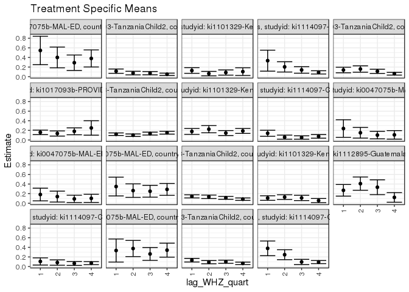

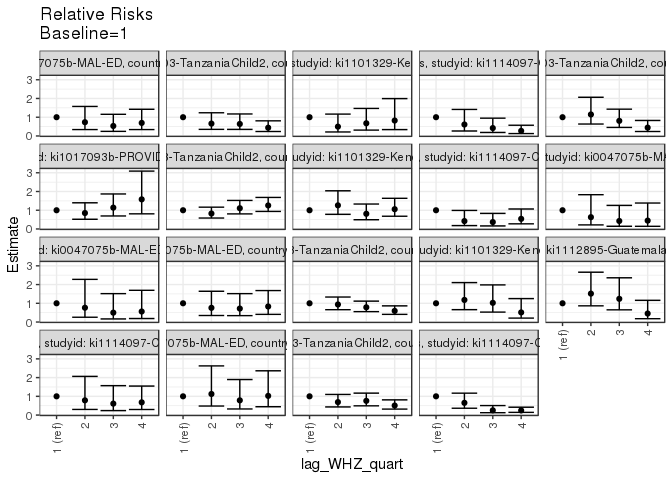

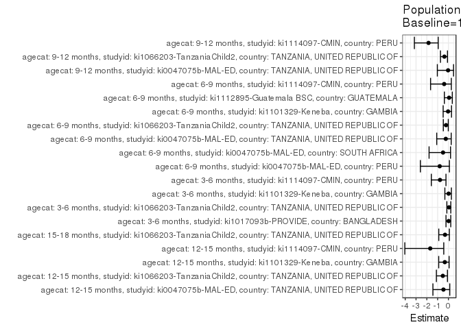

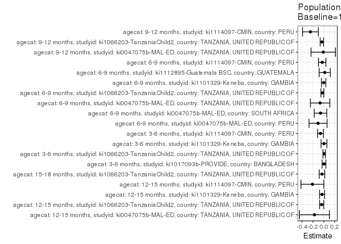

## Results Table

### Parameter: TSM

| agecat | studyid | country | intervention_level | baseline_level | estimate | ci_lower | ci_upper |
| --- | --- | --- | --- | --- | --- | --- | --- |
| 3-6 months | ki1017093b-PROVIDE | BANGLADESH | 1 | NA | 0.1581197 | 0.1113283 | 0.2049111 |
| 3-6 months | ki1017093b-PROVIDE | BANGLADESH | 2 | NA | 0.1346154 | 0.0810054 | 0.1882253 |
| 3-6 months | ki1017093b-PROVIDE | BANGLADESH | 3 | NA | 0.1801802 | 0.1086141 | 0.2517462 |
| 3-6 months | ki1017093b-PROVIDE | BANGLADESH | 4 | NA | 0.2500000 | 0.0998306 | 0.4001694 |
| 3-6 months | ki1066203-TanzaniaChild2 | TANZANIA, UNITED REPUBLIC OF | 1 | NA | 0.1199085 | 0.0933072 | 0.1465099 |
| 3-6 months | ki1066203-TanzaniaChild2 | TANZANIA, UNITED REPUBLIC OF | 2 | NA | 0.0988955 | 0.0726769 | 0.1251141 |
| 3-6 months | ki1066203-TanzaniaChild2 | TANZANIA, UNITED REPUBLIC OF | 3 | NA | 0.1328624 | 0.1025215 | 0.1632034 |
| 3-6 months | ki1066203-TanzaniaChild2 | TANZANIA, UNITED REPUBLIC OF | 4 | NA | 0.1505758 | 0.1217820 | 0.1793696 |
| 3-6 months | ki1101329-Keneba | GAMBIA | 1 | NA | 0.1776308 | 0.1164513 | 0.2388104 |
| 3-6 months | ki1101329-Keneba | GAMBIA | 2 | NA | 0.2242165 | 0.1492352 | 0.2991979 |
| 3-6 months | ki1101329-Keneba | GAMBIA | 3 | NA | 0.1440843 | 0.0923304 | 0.1958381 |
| 3-6 months | ki1101329-Keneba | GAMBIA | 4 | NA | 0.1875992 | 0.1364536 | 0.2387448 |
| 3-6 months | ki1114097-CMIN | PERU | 1 | NA | 0.1391304 | 0.0758228 | 0.2024381 |
| 3-6 months | ki1114097-CMIN | PERU | 2 | NA | 0.0588235 | 0.0165116 | 0.1011355 |
| 3-6 months | ki1114097-CMIN | PERU | 3 | NA | 0.0512821 | 0.0166391 | 0.0859250 |
| 3-6 months | ki1114097-CMIN | PERU | 4 | NA | 0.0752688 | 0.0373212 | 0.1132164 |
| 6-9 months | ki0047075b-MAL-ED | PERU | 1 | NA | 0.2380952 | 0.0553827 | 0.4208078 |
| 6-9 months | ki0047075b-MAL-ED | PERU | 2 | NA | 0.1500000 | 0.0390117 | 0.2609883 |
| 6-9 months | ki0047075b-MAL-ED | PERU | 3 | NA | 0.1016949 | 0.0243400 | 0.1790498 |
| 6-9 months | ki0047075b-MAL-ED | PERU | 4 | NA | 0.1063830 | 0.0179702 | 0.1947958 |
| 6-9 months | ki0047075b-MAL-ED | SOUTH AFRICA | 1 | NA | 0.1818182 | 0.0498426 | 0.3137937 |
| 6-9 months | ki0047075b-MAL-ED | SOUTH AFRICA | 2 | NA | 0.1388889 | 0.0255917 | 0.2521860 |
| 6-9 months | ki0047075b-MAL-ED | SOUTH AFRICA | 3 | NA | 0.0909091 | 0.0147130 | 0.1671052 |
| 6-9 months | ki0047075b-MAL-ED | SOUTH AFRICA | 4 | NA | 0.1020408 | 0.0170398 | 0.1870418 |
| 6-9 months | ki0047075b-MAL-ED | TANZANIA, UNITED REPUBLIC OF | 1 | NA | 0.3478261 | 0.1525721 | 0.5430801 |
| 6-9 months | ki0047075b-MAL-ED | TANZANIA, UNITED REPUBLIC OF | 2 | NA | 0.2631579 | 0.1227134 | 0.4036024 |
| 6-9 months | ki0047075b-MAL-ED | TANZANIA, UNITED REPUBLIC OF | 3 | NA | 0.2500000 | 0.1271200 | 0.3728800 |
| 6-9 months | ki0047075b-MAL-ED | TANZANIA, UNITED REPUBLIC OF | 4 | NA | 0.2884615 | 0.1649401 | 0.4119830 |
| 6-9 months | ki1066203-TanzaniaChild2 | TANZANIA, UNITED REPUBLIC OF | 1 | NA | 0.1433103 | 0.1107809 | 0.1758398 |
| 6-9 months | ki1066203-TanzaniaChild2 | TANZANIA, UNITED REPUBLIC OF | 2 | NA | 0.1342712 | 0.0977647 | 0.1707777 |
| 6-9 months | ki1066203-TanzaniaChild2 | TANZANIA, UNITED REPUBLIC OF | 3 | NA | 0.1126578 | 0.0827009 | 0.1426148 |
| 6-9 months | ki1066203-TanzaniaChild2 | TANZANIA, UNITED REPUBLIC OF | 4 | NA | 0.0850724 | 0.0598474 | 0.1102975 |
| 6-9 months | ki1101329-Keneba | GAMBIA | 1 | NA | 0.1084337 | 0.0610938 | 0.1557737 |
| 6-9 months | ki1101329-Keneba | GAMBIA | 2 | NA | 0.1277778 | 0.0789656 | 0.1765899 |
| 6-9 months | ki1101329-Keneba | GAMBIA | 3 | NA | 0.1111111 | 0.0561899 | 0.1660323 |
| 6-9 months | ki1101329-Keneba | GAMBIA | 4 | NA | 0.0555556 | 0.0123178 | 0.0987933 |
| 6-9 months | ki1112895-Guatemala BSC | GUATEMALA | 1 | NA | 0.2692308 | 0.1483319 | 0.3901296 |
| 6-9 months | ki1112895-Guatemala BSC | GUATEMALA | 2 | NA | 0.4081633 | 0.2701594 | 0.5461672 |
| 6-9 months | ki1112895-Guatemala BSC | GUATEMALA | 3 | NA | 0.3333333 | 0.1789096 | 0.4877570 |
| 6-9 months | ki1112895-Guatemala BSC | GUATEMALA | 4 | NA | 0.1219512 | 0.0215054 | 0.2223971 |
| 6-9 months | ki1114097-CMIN | PERU | 1 | NA | 0.1060606 | 0.0317087 | 0.1804125 |
| 6-9 months | ki1114097-CMIN | PERU | 2 | NA | 0.0833333 | 0.0279968 | 0.1386699 |
| 6-9 months | ki1114097-CMIN | PERU | 3 | NA | 0.0647482 | 0.0238030 | 0.1056934 |
| 6-9 months | ki1114097-CMIN | PERU | 4 | NA | 0.0719697 | 0.0407674 | 0.1031720 |
| 9-12 months | ki0047075b-MAL-ED | TANZANIA, UNITED REPUBLIC OF | 1 | NA | 0.3333333 | 0.0938513 | 0.5728154 |
| 9-12 months | ki0047075b-MAL-ED | TANZANIA, UNITED REPUBLIC OF | 2 | NA | 0.3750000 | 0.2066142 | 0.5433858 |
| 9-12 months | ki0047075b-MAL-ED | TANZANIA, UNITED REPUBLIC OF | 3 | NA | 0.2619048 | 0.1284211 | 0.3953884 |
| 9-12 months | ki0047075b-MAL-ED | TANZANIA, UNITED REPUBLIC OF | 4 | NA | 0.3414634 | 0.1957515 | 0.4871753 |
| 9-12 months | ki1066203-TanzaniaChild2 | TANZANIA, UNITED REPUBLIC OF | 1 | NA | 0.1324267 | 0.0949081 | 0.1699453 |
| 9-12 months | ki1066203-TanzaniaChild2 | TANZANIA, UNITED REPUBLIC OF | 2 | NA | 0.0915608 | 0.0577523 | 0.1253694 |
| 9-12 months | ki1066203-TanzaniaChild2 | TANZANIA, UNITED REPUBLIC OF | 3 | NA | 0.1005775 | 0.0676855 | 0.1334696 |
| 9-12 months | ki1066203-TanzaniaChild2 | TANZANIA, UNITED REPUBLIC OF | 4 | NA | 0.0673243 | 0.0423779 | 0.0922706 |
| 9-12 months | ki1114097-CMIN | PERU | 1 | NA | 0.3784924 | 0.2256428 | 0.5313420 |
| 9-12 months | ki1114097-CMIN | PERU | 2 | NA | 0.2467494 | 0.1430903 | 0.3504085 |
| 9-12 months | ki1114097-CMIN | PERU | 3 | NA | 0.0957767 | 0.0417142 | 0.1498393 |
| 9-12 months | ki1114097-CMIN | PERU | 4 | NA | 0.0929459 | 0.0601312 | 0.1257606 |
| 12-15 months | ki0047075b-MAL-ED | TANZANIA, UNITED REPUBLIC OF | 1 | NA | 0.5454545 | 0.2495721 | 0.8413369 |
| 12-15 months | ki0047075b-MAL-ED | TANZANIA, UNITED REPUBLIC OF | 2 | NA | 0.4000000 | 0.1841072 | 0.6158928 |
| 12-15 months | ki0047075b-MAL-ED | TANZANIA, UNITED REPUBLIC OF | 3 | NA | 0.2903226 | 0.1296515 | 0.4509936 |
| 12-15 months | ki0047075b-MAL-ED | TANZANIA, UNITED REPUBLIC OF | 4 | NA | 0.3793103 | 0.2017348 | 0.5568859 |
| 12-15 months | ki1066203-TanzaniaChild2 | TANZANIA, UNITED REPUBLIC OF | 1 | NA | 0.1141781 | 0.0691099 | 0.1592463 |
| 12-15 months | ki1066203-TanzaniaChild2 | TANZANIA, UNITED REPUBLIC OF | 2 | NA | 0.0752146 | 0.0382216 | 0.1122077 |
| 12-15 months | ki1066203-TanzaniaChild2 | TANZANIA, UNITED REPUBLIC OF | 3 | NA | 0.0730709 | 0.0393305 | 0.1068113 |
| 12-15 months | ki1066203-TanzaniaChild2 | TANZANIA, UNITED REPUBLIC OF | 4 | NA | 0.0500777 | 0.0267526 | 0.0734027 |
| 12-15 months | ki1101329-Keneba | GAMBIA | 1 | NA | 0.1280000 | 0.0693585 | 0.1866415 |
| 12-15 months | ki1101329-Keneba | GAMBIA | 2 | NA | 0.0636364 | 0.0179617 | 0.1093111 |
| 12-15 months | ki1101329-Keneba | GAMBIA | 3 | NA | 0.0865385 | 0.0324344 | 0.1406426 |
| 12-15 months | ki1101329-Keneba | GAMBIA | 4 | NA | 0.1052632 | 0.0254921 | 0.1850343 |
| 12-15 months | ki1114097-CMIN | PERU | 1 | NA | 0.3333333 | 0.1153177 | 0.5513489 |
| 12-15 months | ki1114097-CMIN | PERU | 2 | NA | 0.2037037 | 0.0961637 | 0.3112437 |
| 12-15 months | ki1114097-CMIN | PERU | 3 | NA | 0.1400000 | 0.0719163 | 0.2080837 |
| 12-15 months | ki1114097-CMIN | PERU | 4 | NA | 0.0896057 | 0.0560543 | 0.1231571 |
| 15-18 months | ki1066203-TanzaniaChild2 | TANZANIA, UNITED REPUBLIC OF | 1 | NA | 0.1388060 | 0.0807401 | 0.1968719 |
| 15-18 months | ki1066203-TanzaniaChild2 | TANZANIA, UNITED REPUBLIC OF | 2 | NA | 0.1591026 | 0.0933180 | 0.2248871 |
| 15-18 months | ki1066203-TanzaniaChild2 | TANZANIA, UNITED REPUBLIC OF | 3 | NA | 0.1118359 | 0.0678743 | 0.1557974 |
| 15-18 months | ki1066203-TanzaniaChild2 | TANZANIA, UNITED REPUBLIC OF | 4 | NA | 0.0616025 | 0.0332326 | 0.0899724 |

### Parameter: E(Y)

| agecat | studyid | country | intervention_level | baseline_level | estimate | ci_lower | ci_upper |
| --- | --- | --- | --- | --- | --- | --- | --- |
| 3-6 months | ki1017093b-PROVIDE | BANGLADESH | NA | NA | 0.1613508 | 0.1300924 | 0.1926093 |
| 3-6 months | ki1066203-TanzaniaChild2 | TANZANIA, UNITED REPUBLIC OF | NA | NA | 0.1268012 | 0.1125046 | 0.1410977 |
| 3-6 months | ki1101329-Keneba | GAMBIA | NA | NA | 0.1808511 | 0.1514199 | 0.2102822 |
| 3-6 months | ki1114097-CMIN | PERU | NA | NA | 0.0781250 | 0.0561896 | 0.1000604 |
| 6-9 months | ki0047075b-MAL-ED | PERU | NA | NA | 0.1317365 | 0.0802880 | 0.1831851 |
| 6-9 months | ki0047075b-MAL-ED | SOUTH AFRICA | NA | NA | 0.1213873 | 0.0725817 | 0.1701928 |
| 6-9 months | ki0047075b-MAL-ED | TANZANIA, UNITED REPUBLIC OF | NA | NA | 0.2795031 | 0.2099691 | 0.3490371 |
| 6-9 months | ki1066203-TanzaniaChild2 | TANZANIA, UNITED REPUBLIC OF | NA | NA | 0.1174017 | 0.1019953 | 0.1328080 |
| 6-9 months | ki1101329-Keneba | GAMBIA | NA | NA | 0.1051724 | 0.0801845 | 0.1301603 |
| 6-9 months | ki1112895-Guatemala BSC | GUATEMALA | NA | NA | 0.2865169 | 0.2199085 | 0.3531252 |
| 6-9 months | ki1114097-CMIN | PERU | NA | NA | 0.0761062 | 0.0542221 | 0.0979903 |
| 9-12 months | ki0047075b-MAL-ED | TANZANIA, UNITED REPUBLIC OF | NA | NA | 0.3230769 | 0.2423765 | 0.4037774 |
| 9-12 months | ki1066203-TanzaniaChild2 | TANZANIA, UNITED REPUBLIC OF | NA | NA | 0.0964230 | 0.0802843 | 0.1125618 |
| 9-12 months | ki1114097-CMIN | PERU | NA | NA | 0.1332046 | 0.1039145 | 0.1624947 |
| 12-15 months | ki0047075b-MAL-ED | TANZANIA, UNITED REPUBLIC OF | NA | NA | 0.3736264 | 0.2736811 | 0.4735717 |
| 12-15 months | ki1066203-TanzaniaChild2 | TANZANIA, UNITED REPUBLIC OF | NA | NA | 0.0752119 | 0.0583791 | 0.0920447 |
| 12-15 months | ki1101329-Keneba | GAMBIA | NA | NA | 0.0959596 | 0.0669135 | 0.1250057 |
| 12-15 months | ki1114097-CMIN | PERU | NA | NA | 0.1241685 | 0.0936995 | 0.1546375 |
| 15-18 months | ki1066203-TanzaniaChild2 | TANZANIA, UNITED REPUBLIC OF | NA | NA | 0.1056241 | 0.0832975 | 0.1279508 |

### Parameter: RR

| agecat | studyid | country | intervention_level | baseline_level | estimate | ci_lower | ci_upper |
| --- | --- | --- | --- | --- | --- | --- | --- |
| 3-6 months | ki1017093b-PROVIDE | BANGLADESH | 1 | 1 | 1.0000000 | 1.0000000 | 1.0000000 |
| 3-6 months | ki1017093b-PROVIDE | BANGLADESH | 2 | 1 | 0.8513514 | 0.5183596 | 1.3982554 |
| 3-6 months | ki1017093b-PROVIDE | BANGLADESH | 3 | 1 | 1.1395179 | 0.6944015 | 1.8699571 |
| 3-6 months | ki1017093b-PROVIDE | BANGLADESH | 4 | 1 | 1.5810811 | 0.8093640 | 3.0886194 |
| 3-6 months | ki1066203-TanzaniaChild2 | TANZANIA, UNITED REPUBLIC OF | 1 | 1 | 1.0000000 | 1.0000000 | 1.0000000 |
| 3-6 months | ki1066203-TanzaniaChild2 | TANZANIA, UNITED REPUBLIC OF | 2 | 1 | 0.8247580 | 0.5837124 | 1.1653439 |
| 3-6 months | ki1066203-TanzaniaChild2 | TANZANIA, UNITED REPUBLIC OF | 3 | 1 | 1.1080315 | 0.8059013 | 1.5234295 |
| 3-6 months | ki1066203-TanzaniaChild2 | TANZANIA, UNITED REPUBLIC OF | 4 | 1 | 1.2557554 | 0.9369298 | 1.6830734 |
| 3-6 months | ki1101329-Keneba | GAMBIA | 1 | 1 | 1.0000000 | 1.0000000 | 1.0000000 |
| 3-6 months | ki1101329-Keneba | GAMBIA | 2 | 1 | 1.2622614 | 0.7817008 | 2.0382529 |
| 3-6 months | ki1101329-Keneba | GAMBIA | 3 | 1 | 0.8111444 | 0.4937106 | 1.3326738 |
| 3-6 months | ki1101329-Keneba | GAMBIA | 4 | 1 | 1.0561184 | 0.6813533 | 1.6370157 |
| 3-6 months | ki1114097-CMIN | PERU | 1 | 1 | 1.0000000 | 1.0000000 | 1.0000000 |
| 3-6 months | ki1114097-CMIN | PERU | 2 | 1 | 0.4227941 | 0.1805022 | 0.9903197 |
| 3-6 months | ki1114097-CMIN | PERU | 3 | 1 | 0.3685897 | 0.1632353 | 0.8322857 |
| 3-6 months | ki1114097-CMIN | PERU | 4 | 1 | 0.5409946 | 0.2743141 | 1.0669343 |
| 6-9 months | ki0047075b-MAL-ED | PERU | 1 | 1 | 1.0000000 | 1.0000000 | 1.0000000 |
| 6-9 months | ki0047075b-MAL-ED | PERU | 2 | 1 | 0.6300000 | 0.2169594 | 1.8293746 |
| 6-9 months | ki0047075b-MAL-ED | PERU | 3 | 1 | 0.4271186 | 0.1449744 | 1.2583621 |
| 6-9 months | ki0047075b-MAL-ED | PERU | 4 | 1 | 0.4468085 | 0.1441627 | 1.3848096 |
| 6-9 months | ki0047075b-MAL-ED | SOUTH AFRICA | 1 | 1 | 1.0000000 | 1.0000000 | 1.0000000 |
| 6-9 months | ki0047075b-MAL-ED | SOUTH AFRICA | 2 | 1 | 0.7638889 | 0.2563368 | 2.2764049 |
| 6-9 months | ki0047075b-MAL-ED | SOUTH AFRICA | 3 | 1 | 0.5000000 | 0.1649810 | 1.5153263 |
| 6-9 months | ki0047075b-MAL-ED | SOUTH AFRICA | 4 | 1 | 0.5612245 | 0.1859037 | 1.6942799 |
| 6-9 months | ki0047075b-MAL-ED | TANZANIA, UNITED REPUBLIC OF | 1 | 1 | 1.0000000 | 1.0000000 | 1.0000000 |
| 6-9 months | ki0047075b-MAL-ED | TANZANIA, UNITED REPUBLIC OF | 2 | 1 | 0.7565789 | 0.3487121 | 1.6415023 |
| 6-9 months | ki0047075b-MAL-ED | TANZANIA, UNITED REPUBLIC OF | 3 | 1 | 0.7187500 | 0.3408296 | 1.5157180 |
| 6-9 months | ki0047075b-MAL-ED | TANZANIA, UNITED REPUBLIC OF | 4 | 1 | 0.8293269 | 0.4093547 | 1.6801641 |
| 6-9 months | ki1066203-TanzaniaChild2 | TANZANIA, UNITED REPUBLIC OF | 1 | 1 | 1.0000000 | 1.0000000 | 1.0000000 |
| 6-9 months | ki1066203-TanzaniaChild2 | TANZANIA, UNITED REPUBLIC OF | 2 | 1 | 0.9369259 | 0.6575222 | 1.3350578 |
| 6-9 months | ki1066203-TanzaniaChild2 | TANZANIA, UNITED REPUBLIC OF | 3 | 1 | 0.7861109 | 0.5542067 | 1.1150538 |
| 6-9 months | ki1066203-TanzaniaChild2 | TANZANIA, UNITED REPUBLIC OF | 4 | 1 | 0.5936238 | 0.4086606 | 0.8623030 |
| 6-9 months | ki1101329-Keneba | GAMBIA | 1 | 1 | 1.0000000 | 1.0000000 | 1.0000000 |
| 6-9 months | ki1101329-Keneba | GAMBIA | 2 | 1 | 1.1783951 | 0.6597065 | 2.1048980 |
| 6-9 months | ki1101329-Keneba | GAMBIA | 3 | 1 | 1.0246914 | 0.5298841 | 1.9815512 |
| 6-9 months | ki1101329-Keneba | GAMBIA | 4 | 1 | 0.5123457 | 0.2099001 | 1.2505857 |
| 6-9 months | ki1112895-Guatemala BSC | GUATEMALA | 1 | 1 | 1.0000000 | 1.0000000 | 1.0000000 |
| 6-9 months | ki1112895-Guatemala BSC | GUATEMALA | 2 | 1 | 1.5160350 | 0.8641484 | 2.6596843 |
| 6-9 months | ki1112895-Guatemala BSC | GUATEMALA | 3 | 1 | 1.2380952 | 0.6494595 | 2.3602392 |
| 6-9 months | ki1112895-Guatemala BSC | GUATEMALA | 4 | 1 | 0.4529617 | 0.1772735 | 1.1573883 |
| 6-9 months | ki1114097-CMIN | PERU | 1 | 1 | 1.0000000 | 1.0000000 | 1.0000000 |
| 6-9 months | ki1114097-CMIN | PERU | 2 | 1 | 0.7857143 | 0.2991628 | 2.0635816 |
| 6-9 months | ki1114097-CMIN | PERU | 3 | 1 | 0.6104830 | 0.2374933 | 1.5692635 |
| 6-9 months | ki1114097-CMIN | PERU | 4 | 1 | 0.6785714 | 0.2975930 | 1.5472783 |
| 9-12 months | ki0047075b-MAL-ED | TANZANIA, UNITED REPUBLIC OF | 1 | 1 | 1.0000000 | 1.0000000 | 1.0000000 |
| 9-12 months | ki0047075b-MAL-ED | TANZANIA, UNITED REPUBLIC OF | 2 | 1 | 1.1250000 | 0.4821775 | 2.6248115 |
| 9-12 months | ki0047075b-MAL-ED | TANZANIA, UNITED REPUBLIC OF | 3 | 1 | 0.7857143 | 0.3256190 | 1.8959178 |
| 9-12 months | ki0047075b-MAL-ED | TANZANIA, UNITED REPUBLIC OF | 4 | 1 | 1.0243902 | 0.4441811 | 2.3624944 |
| 9-12 months | ki1066203-TanzaniaChild2 | TANZANIA, UNITED REPUBLIC OF | 1 | 1 | 1.0000000 | 1.0000000 | 1.0000000 |
| 9-12 months | ki1066203-TanzaniaChild2 | TANZANIA, UNITED REPUBLIC OF | 2 | 1 | 0.6914076 | 0.4341740 | 1.1010437 |
| 9-12 months | ki1066203-TanzaniaChild2 | TANZANIA, UNITED REPUBLIC OF | 3 | 1 | 0.7594958 | 0.4927406 | 1.1706643 |
| 9-12 months | ki1066203-TanzaniaChild2 | TANZANIA, UNITED REPUBLIC OF | 4 | 1 | 0.5083890 | 0.3189075 | 0.8104525 |
| 9-12 months | ki1114097-CMIN | PERU | 1 | 1 | 1.0000000 | 1.0000000 | 1.0000000 |
| 9-12 months | ki1114097-CMIN | PERU | 2 | 1 | 0.6519270 | 0.3640264 | 1.1675217 |
| 9-12 months | ki1114097-CMIN | PERU | 3 | 1 | 0.2530480 | 0.1264142 | 0.5065353 |
| 9-12 months | ki1114097-CMIN | PERU | 4 | 1 | 0.2455688 | 0.1435973 | 0.4199523 |
| 12-15 months | ki0047075b-MAL-ED | TANZANIA, UNITED REPUBLIC OF | 1 | 1 | 1.0000000 | 1.0000000 | 1.0000000 |
| 12-15 months | ki0047075b-MAL-ED | TANZANIA, UNITED REPUBLIC OF | 2 | 1 | 0.7333333 | 0.3411693 | 1.5762782 |
| 12-15 months | ki0047075b-MAL-ED | TANZANIA, UNITED REPUBLIC OF | 3 | 1 | 0.5322581 | 0.2452284 | 1.1552440 |
| 12-15 months | ki0047075b-MAL-ED | TANZANIA, UNITED REPUBLIC OF | 4 | 1 | 0.6954023 | 0.3396639 | 1.4237145 |
| 12-15 months | ki1066203-TanzaniaChild2 | TANZANIA, UNITED REPUBLIC OF | 1 | 1 | 1.0000000 | 1.0000000 | 1.0000000 |
| 12-15 months | ki1066203-TanzaniaChild2 | TANZANIA, UNITED REPUBLIC OF | 2 | 1 | 0.6587483 | 0.3506049 | 1.2377163 |
| 12-15 months | ki1066203-TanzaniaChild2 | TANZANIA, UNITED REPUBLIC OF | 3 | 1 | 0.6399728 | 0.3489782 | 1.1736127 |
| 12-15 months | ki1066203-TanzaniaChild2 | TANZANIA, UNITED REPUBLIC OF | 4 | 1 | 0.4385926 | 0.2382438 | 0.8074229 |
| 12-15 months | ki1101329-Keneba | GAMBIA | 1 | 1 | 1.0000000 | 1.0000000 | 1.0000000 |
| 12-15 months | ki1101329-Keneba | GAMBIA | 2 | 1 | 0.4971591 | 0.2121753 | 1.1649198 |
| 12-15 months | ki1101329-Keneba | GAMBIA | 3 | 1 | 0.6760817 | 0.3114446 | 1.4676333 |
| 12-15 months | ki1101329-Keneba | GAMBIA | 4 | 1 | 0.8223684 | 0.3392184 | 1.9936709 |
| 12-15 months | ki1114097-CMIN | PERU | 1 | 1 | 1.0000000 | 1.0000000 | 1.0000000 |
| 12-15 months | ki1114097-CMIN | PERU | 2 | 1 | 0.6111111 | 0.2636849 | 1.4162996 |
| 12-15 months | ki1114097-CMIN | PERU | 3 | 1 | 0.4200000 | 0.1859026 | 0.9488840 |
| 12-15 months | ki1114097-CMIN | PERU | 4 | 1 | 0.2688172 | 0.1265185 | 0.5711630 |
| 15-18 months | ki1066203-TanzaniaChild2 | TANZANIA, UNITED REPUBLIC OF | 1 | 1 | 1.0000000 | 1.0000000 | 1.0000000 |
| 15-18 months | ki1066203-TanzaniaChild2 | TANZANIA, UNITED REPUBLIC OF | 2 | 1 | 1.1462227 | 0.6364710 | 2.0642363 |
| 15-18 months | ki1066203-TanzaniaChild2 | TANZANIA, UNITED REPUBLIC OF | 3 | 1 | 0.8056992 | 0.4537732 | 1.4305632 |
| 15-18 months | ki1066203-TanzaniaChild2 | TANZANIA, UNITED REPUBLIC OF | 4 | 1 | 0.4438030 | 0.2382030 | 0.8268622 |

### Parameter: PAR

| agecat | studyid | country | intervention_level | baseline_level | estimate | ci_lower | ci_upper |
| --- | --- | --- | --- | --- | --- | --- | --- |
| 3-6 months | ki1017093b-PROVIDE | BANGLADESH | 1 | NA | 0.0032312 | -0.0320406 | 0.0385030 |
| 3-6 months | ki1066203-TanzaniaChild2 | TANZANIA, UNITED REPUBLIC OF | 1 | NA | 0.0068926 | -0.0160770 | 0.0298622 |
| 3-6 months | ki1101329-Keneba | GAMBIA | 1 | NA | 0.0032202 | -0.0504965 | 0.0569369 |
| 3-6 months | ki1114097-CMIN | PERU | 1 | NA | -0.0610054 | -0.1147517 | -0.0072592 |
| 6-9 months | ki0047075b-MAL-ED | PERU | 1 | NA | -0.1063587 | -0.2725961 | 0.0598787 |
| 6-9 months | ki0047075b-MAL-ED | SOUTH AFRICA | 1 | NA | -0.0604309 | -0.1751248 | 0.0542630 |
| 6-9 months | ki0047075b-MAL-ED | TANZANIA, UNITED REPUBLIC OF | 1 | NA | -0.0683230 | -0.2473942 | 0.1107482 |
| 6-9 months | ki1066203-TanzaniaChild2 | TANZANIA, UNITED REPUBLIC OF | 1 | NA | -0.0259087 | -0.0529732 | 0.0011558 |
| 6-9 months | ki1101329-Keneba | GAMBIA | 1 | NA | -0.0032613 | -0.0430438 | 0.0365212 |
| 6-9 months | ki1112895-Guatemala BSC | GUATEMALA | 1 | NA | 0.0172861 | -0.0852478 | 0.1198200 |
| 6-9 months | ki1114097-CMIN | PERU | 1 | NA | -0.0299544 | -0.0986244 | 0.0387156 |
| 9-12 months | ki0047075b-MAL-ED | TANZANIA, UNITED REPUBLIC OF | 1 | NA | -0.0102564 | -0.2352658 | 0.2147530 |
| 9-12 months | ki1066203-TanzaniaChild2 | TANZANIA, UNITED REPUBLIC OF | 1 | NA | -0.0360037 | -0.0673993 | -0.0046080 |
| 9-12 months | ki1114097-CMIN | PERU | 1 | NA | -0.2452878 | -0.3895388 | -0.1010368 |
| 12-15 months | ki0047075b-MAL-ED | TANZANIA, UNITED REPUBLIC OF | 1 | NA | -0.1718282 | -0.4481801 | 0.1045238 |
| 12-15 months | ki1066203-TanzaniaChild2 | TANZANIA, UNITED REPUBLIC OF | 1 | NA | -0.0389662 | -0.0775472 | -0.0003853 |
| 12-15 months | ki1101329-Keneba | GAMBIA | 1 | NA | -0.0320404 | -0.0779918 | 0.0139109 |
| 12-15 months | ki1114097-CMIN | PERU | 1 | NA | -0.2091648 | -0.4205061 | 0.0021765 |
| 15-18 months | ki1066203-TanzaniaChild2 | TANZANIA, UNITED REPUBLIC OF | 1 | NA | -0.0331818 | -0.0842214 | 0.0178577 |

### Parameter: PAF

| agecat | studyid | country | intervention_level | baseline_level | estimate | ci_lower | ci_upper |
| --- | --- | --- | --- | --- | --- | --- | --- |
| 3-6 months | ki1017093b-PROVIDE | BANGLADESH | 1 | NA | 0.0200258 | -0.2248509 | 0.2159459 |
| 3-6 months | ki1066203-TanzaniaChild2 | TANZANIA, UNITED REPUBLIC OF | 1 | NA | 0.0543576 | -0.1451527 | 0.2191090 |
| 3-6 months | ki1101329-Keneba | GAMBIA | 1 | NA | 0.0178060 | -0.3290257 | 0.2741261 |
| 3-6 months | ki1114097-CMIN | PERU | 1 | NA | -0.7808696 | -1.5843007 | -0.2272165 |
| 6-9 months | ki0047075b-MAL-ED | PERU | 1 | NA | -0.8073593 | -2.5971848 | 0.0919155 |
| 6-9 months | ki0047075b-MAL-ED | SOUTH AFRICA | 1 | NA | -0.4978355 | -1.7912392 | 0.1962311 |
| 6-9 months | ki0047075b-MAL-ED | TANZANIA, UNITED REPUBLIC OF | 1 | NA | -0.2444444 | -1.0822290 | 0.2562576 |
| 6-9 months | ki1066203-TanzaniaChild2 | TANZANIA, UNITED REPUBLIC OF | 1 | NA | -0.2206841 | -0.4729079 | -0.0116516 |
| 6-9 months | ki1101329-Keneba | GAMBIA | 1 | NA | -0.0310093 | -0.4879038 | 0.2855854 |
| 6-9 months | ki1112895-Guatemala BSC | GUATEMALA | 1 | NA | 0.0603318 | -0.3751187 | 0.3578909 |
| 6-9 months | ki1114097-CMIN | PERU | 1 | NA | -0.3935870 | -1.6522424 | 0.2677574 |
| 9-12 months | ki0047075b-MAL-ED | TANZANIA, UNITED REPUBLIC OF | 1 | NA | -0.0317460 | -1.0264390 | 0.4746943 |
| 9-12 months | ki1066203-TanzaniaChild2 | TANZANIA, UNITED REPUBLIC OF | 1 | NA | -0.3733932 | -0.7357876 | -0.0866588 |
| 9-12 months | ki1114097-CMIN | PERU | 1 | NA | -1.8414357 | -3.1514260 | -0.9448153 |
| 12-15 months | ki0047075b-MAL-ED | TANZANIA, UNITED REPUBLIC OF | 1 | NA | -0.4598930 | -1.4355662 | 0.1249313 |
| 12-15 months | ki1066203-TanzaniaChild2 | TANZANIA, UNITED REPUBLIC OF | 1 | NA | -0.5180863 | -1.1141852 | -0.0900587 |
| 12-15 months | ki1101329-Keneba | GAMBIA | 1 | NA | -0.3338947 | -0.8989858 | 0.0630392 |
| 12-15 months | ki1114097-CMIN | PERU | 1 | NA | -1.6845238 | -4.0381860 | -0.4304093 |
| 15-18 months | ki1066203-TanzaniaChild2 | TANZANIA, UNITED REPUBLIC OF | 1 | NA | -0.3141501 | -0.8934734 | 0.0879246 |